# Assignment 8

Lindsey Winslow

2024-04-11

1. Read the data file unpopular_songs.csv using the read_csv() function in tidyverse and call this data frame songs.

```r
library(tidyverse)
songs<- read_csv("~/Desktop/MTH 209/unpopular_songs.csv")
```

2. Get a glimpse of the data and indicate the number of observations and the number of variables in the data.

```r
glimpse(songs)
```

```
## Rows: 10,877
## Columns: 17
## $ danceability     <dbl> 0.530, 0.565, 0.427, 0.421, 0.537, 0.710, 0.419, 0.56…
## $ energy           <dbl> 0.770, 0.730, 0.546, 0.531, 0.804, 0.621, 0.821, 0.62…
## $ key              <dbl> 4, 1, 4, 7, 8, 9, 11, 1, 0, 5, 2, 2, 0, 0, 5, 10, 11,…
## $ loudness         <dbl> -6.633, -6.063, -8.727, -5.516, -7.378, -7.879, -5.76…
## $ mode             <dbl> 0, 1, 1, 1, 0, 0, 0, 1, 1, 1, 0, 1, 1, 1, 1, 1, 0, 0,…
## $ speechiness      <dbl> 0.0389, 0.0730, 0.0849, 0.0262, 0.1570, 0.0329, 0.043…
## $ acousticness     <dbl> 0.28400, 0.36500, 0.53900, 0.70600, 0.37900, 0.40500,…
## $ instrumentalness <dbl> 0.501000, 0.000000, 0.015200, 0.000208, 0.000489, 0.0…
## $ liveness         <dbl> 0.7440, 0.2370, 0.3680, 0.1100, 0.3230, 0.1030, 0.127…
## $ valence          <dbl> 0.623, 0.511, 0.435, 0.383, 0.543, 0.546, 0.343, 0.65…
## $ tempo            <dbl> 120.144, 130.026, 78.345, 85.080, 139.950, 125.985, 8…
## $ duration_ms      <dbl> 225696, 158093, 167262, 236832, 239400, 194560, 19528…
## $ explicit         <lgl> FALSE, FALSE, FALSE, FALSE, FALSE, FALSE, FALSE, FALS…
## $ popularity       <dbl> 2, 2, 2, 2, 2, 2, 2, 2, 2, 2, 2, 2, 2, 13, 5, 14, 14,…
## $ track_name       <chr> "No Regrets", "Wild Life", "Fangs", "Afterburner", "H…
## $ track_artist     <chr> "James Reeder", "James Reeder", "James Reeder", "Jame…
## $ track_id         <chr> "6f2c4a9lNx8aowZJngv7cJ", "3fTs52jsDzSuVLsifxNKO8", "…
```

There are 10877 observations and 17 variables in this dataset.

3. Find how many songs that have danceability higher than the median dancebility, energy lower than the median energy, loudness lower than the median loudness, speechiness higher than the medain speechiness, and the popularity is 1.

```r
songs %>%
  filter(danceability>median(danceability), energy<median(energy), loudness<median(loudness), speechiness>median(speechiness), popularity==1)
```

```
## # A tibble: 288 × 17
##    danceability energy   key loudness  mode speechiness acousticness
##           <dbl>  <dbl> <dbl>    <dbl> <dbl>       <dbl>        <dbl>
##  1        0.815  0.372     9   -14.9      1      0.161       0.785
##  2        0.708  0.389     0   -13.8      1      0.118       0.305
##  3        0.706  0.259     6   -12.4      1      0.0746      0.0322
##  4        0.779  0.402     5   -13.9      0      0.0652      0.00751
##  5        0.8    0.36      4   -17.8      0      0.168       0.035
##  6        0.81   0.138    11   -17.3      1      0.0621      0.0292
##  7        0.752  0.383     9   -16.9      1      0.0681      0.00366
##  8        0.807  0.401    10   -11.3      0      0.393       0.165
##  9        0.907  0.416     7   -10.4      1      0.327       0.238
## 10        0.807  0.519    11    -9.65     1      0.262       0.117
## # ℹ 278 more rows
## # ℹ 10 more variables: instrumentalness <dbl>, liveness <dbl>, valence <dbl>,
## #   tempo <dbl>, duration_ms <dbl>, explicit <lgl>, popularity <dbl>,
## #   track_name <chr>, track_artist <chr>, track_id <chr>
```

288 songs satisfy these conditions.

4. Sort the data frame songs by popularity, duration_ms via decending order, and key, and save the result back to the original data frame. Then only print the first 5 songs.

```r
songs<- songs %>%
  arrange(popularity, desc(duration_ms), key)
head(songs,5)
```

```
## # A tibble: 5 × 17
##   danceability energy   key loudness  mode speechiness acousticness
##          <dbl>  <dbl> <dbl>    <dbl> <dbl>       <dbl>        <dbl>
## 1        0.486  0.799     8    -4.82     1      0.0529      0.014
## 2        0.217  0.614     0   -12.0      1      0.0432      0.609
## 3        0.252  0.371     2   -24.7      1      0.0879      0.821
## 4        0.122  0.906     2    -5.18     1      0.0727      0.00978
## 5        0.363  0.881     1    -3.78     1      0.464       0.0169
## # ℹ 10 more variables: instrumentalness <dbl>, liveness <dbl>, valence <dbl>,
## #   tempo <dbl>, duration_ms <dbl>, explicit <lgl>, popularity <dbl>,
## #   track_name <chr>, track_artist <chr>, track_id <chr>
```

5. Change the data type of popularity to a factor in the data frame songs and create a boxplot of the distribution of duration_ms by popularity. Discuss the distribution of durations_ms by popularity

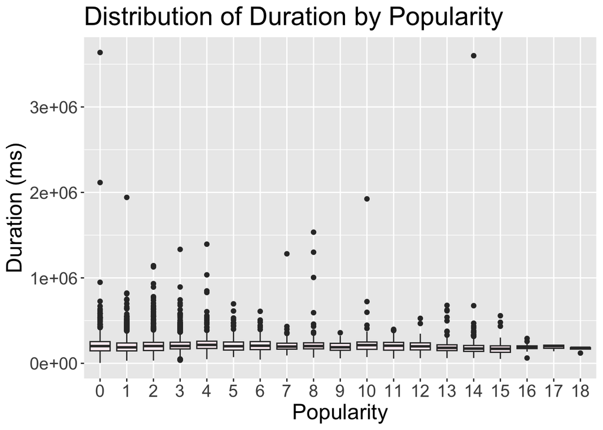

```r
songs$popularity<- as.factor(songs$popularity)
ggplot(songs, aes(x=popularity, y=duration_ms))+
  geom_boxplot(fill="#FFF0F5")+
  labs(title="Distribution of Duration by Popularity", x="Popularity", y="Duration (ms)")+
  theme(text=element_text(size=18))
```

Most of the songs, no matter the popularity, have a similar duration. The medians are all around 200000ms. There are many outliers, but there seem to be more in the songs with lower popularity.

6. Create a boxplot of the distribution of instrumentalness by popularity. Discuss the distribution of instrumentalness by popularity.

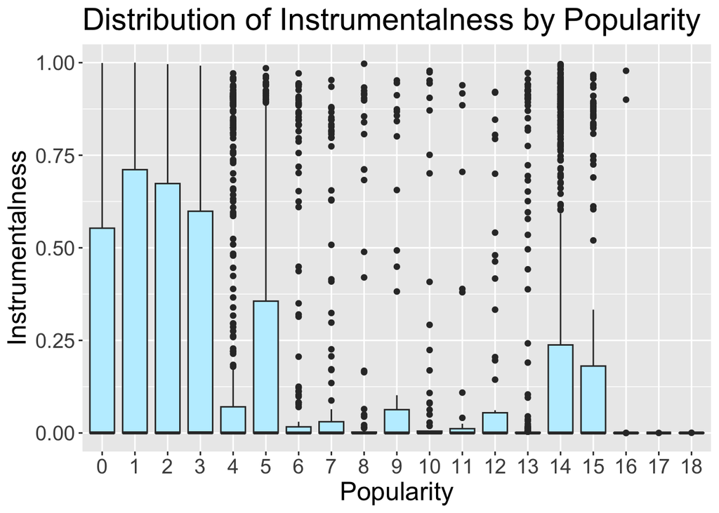

```r
ggplot(songs, aes(x=popularity, y=instrumentalness))+
  geom_boxplot(fill="#BFEFFF")+
  labs(title="Distribution of Instrumentalness by Popularity", x="Popularity", y="Instrumentalness")+
  theme(text=element_text(size=18))
```

The songs with the lowest popularity have the biggest IQRs and no outliers. The middle popularity songs have very small IQRs and many large outliers. Then a couple of larger popularity categories have a mid size IQR and outliers. The largest three song popularity categories are at 0 meaning no instrumentalness. All of the boxplots seem very right skewed.

7. What do you find based on the boxplots in Questions 4 and 5.

For the duration boxplots, since there are more large outliers in the low popularity groups, this might mean that longer songs are less popular and shorter songs are more popular. For the instrumentalness boxplots, the least popular songs have a higher instrumentalness which means they have more instrumentals and less vocals. The most popular songs are full of vocals without instrumentals.

8. Create a histogram to show the distribution of instrumentalness and describe the distribution.

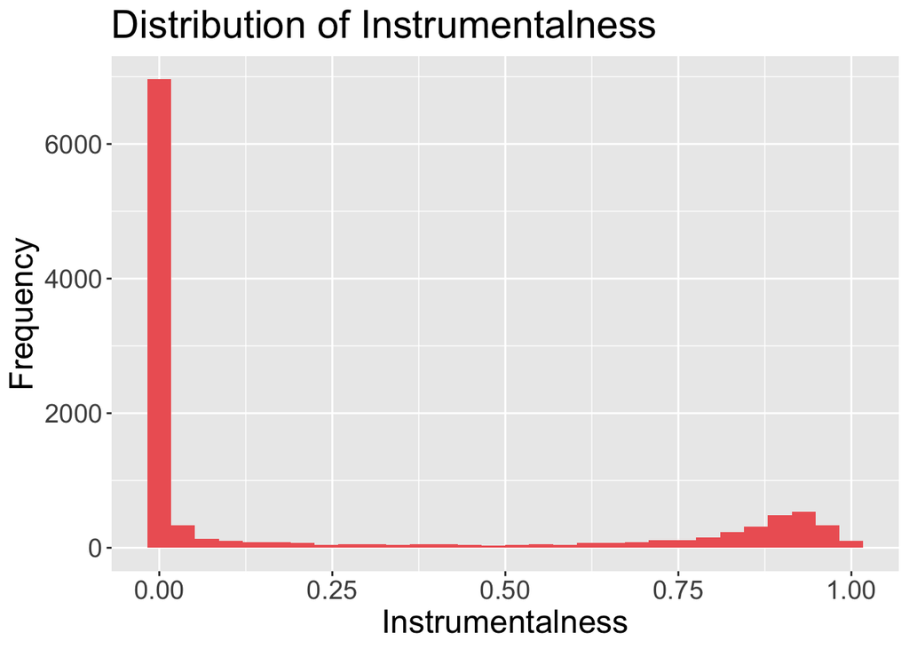

```r
ggplot(songs, aes(x=instrumentalness))+
  geom_histogram(fill="#EE6363")+
  labs(title="Distribution of Instrumentalness", x="Instrumentalness", y="Frequency")+
  theme(text=element_text(size=18))
```

This histogram is very right skewed. The median is 0.000133, so all the way to the left. The middle values are very uncommon and then it picks up a little bit toward the high values. This means that most songs have vocals but there are some songs with mostly instrumentals. There are very few songs that are a mix of both.

9. Group the data frame songs by track_artist and find the correspond median, Q3 - Q1 for danceability, energy, speechiness, acousticness, instrumentalness, liveness, valence and counts for each track_artist. Save the result to unpopular_artists and sort the data frame via the descending order of counts. Print the top 10 unpopular artists and the corresponding information in unpopular_artists. Summaize your finding based on the result shown here.

```r
unpopular_artists<-songs %>%
  group_by(track_artist) %>%
  summarize(med_danceability=median(danceability),
            med_energy=median(energy),
            med_speechiness=median(speechiness),
            med_acousticness=median(acousticness),
            med_instrumentalness=median(instrumentalness),
            med_liveness=median(liveness),
            med_valence=median(valence),
            counts=n()) %>%
  arrange(desc(counts))
head(unpopular_artists,10)
```

```
## # A tibble: 10 × 9
##    track_artist     med_danceability med_energy med_speechiness med_acousticness
##    <chr>                       <dbl>      <dbl>           <dbl>            <dbl>
##  1 Alei Islah                  0.784     0.542           0.302           0.582
##  2 Ocean Sounds                0.175     0.860           0.0598          0.392
##  3 Blackjesus Yosh…            0.704     0.397           0.0453          0.0340
##  4 Native American…            0.454     0.0426          0.131           0.992
##  5 Paris Street                0.492     0.288           0.0339          0.885
##  6 Sounds Of Natur…            0.170     0.999           0.0634          0.420
##  7 Sounds of Natur…            0.191     0.196           0.0495          0
##  8 Yoga Playlist               0.25      0.108           0.0436          0.965
##  9 Manic Vertex                0.476     0.664           0.0371          0.00301
## 10 Outside Broadca…            0.168     0.998           0.0584          0.453
## # ℹ 4 more variables: med_instrumentalness <dbl>, med_liveness <dbl>,
## #   med_valence <dbl>, counts <int>
```

Looking at the artists with the most unpopular songs, I noticed that a lot of them have a high median instrumentalness which makes sense because when I think of popular songs, they all have vocals. There are also some artists with high acousticness which also makes sense because most songs are not acoustic these days. Most have low danceability, speechiness, liveness, and valence. Energy is pretty mixed with some pretty high and some pretty low.

10. Create two new variables: instrumentalness_status and boringness in the data frame songs. The variable instrumentalness_status has the value “High” for the songs that their instrumentalness is higher than the mean instrumentalness, otherwise it is “Low”. The variable boringness is calculated by boringness = loudness + tempo + (energy*100) + (danceability*100) Hint: You can use this command ifelse(condition, value1, value2), it assigns value 1 to the new variable when the condition is TRUE, otherwise it assign value 2 to the variable.

```r
songs<- songs %>%
  mutate(instrumentalness_status=
           ifelse(instrumentalness>mean(instrumentalness), "High", "Low"),
    boringness=loudness + tempo + (energy*100) + (danceability*100))
```

11. Create a bar plot that shows the conditional distribution of instrumentalness_status by the popularity of songs. Comment on your barplot.

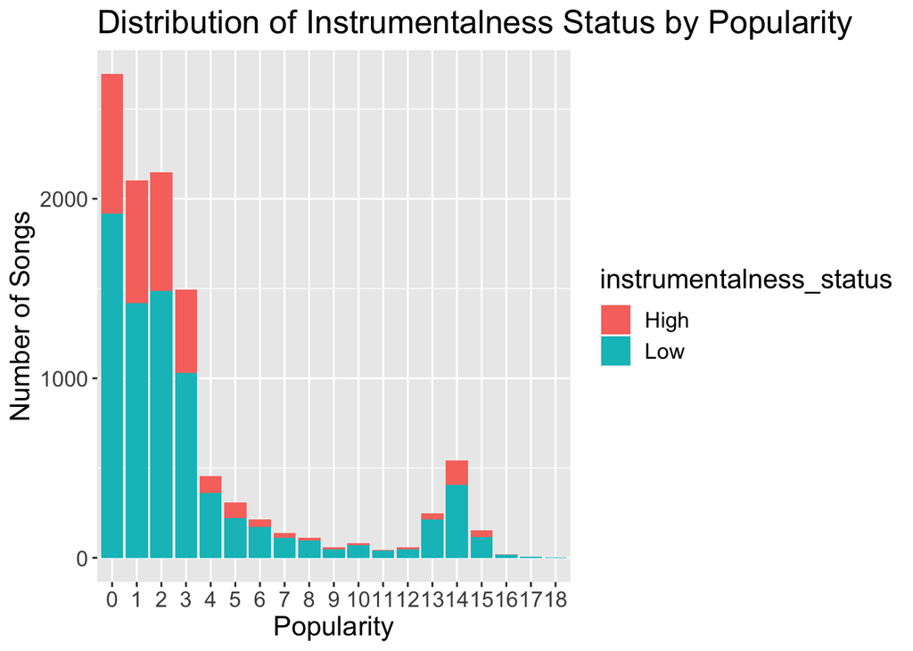

```r
ggplot(songs, aes(x=popularity, fill=instrumentalness_status))+
  geom_bar()+
  labs(title="Distribution of Instrumentalness Status by Popularity", x="Popularity", y="Number of Songs")+
  theme(text=element_text(size=15))
```

There are mostly songs with low popularity ratings in this dataset. All of the popularity categories have more low instrumentalness than high instrumentalness songs. There is a little spike in frequency at popularity 13-15, but we can see that there are very few mid and high popularity songs in the dataset.

12. Create a boxplot that shows the distribution of boringness by the popularity of songs. Comment on your boxplot. What did you find based on the boxplot. Hint: You should recall how this variable was calculated.

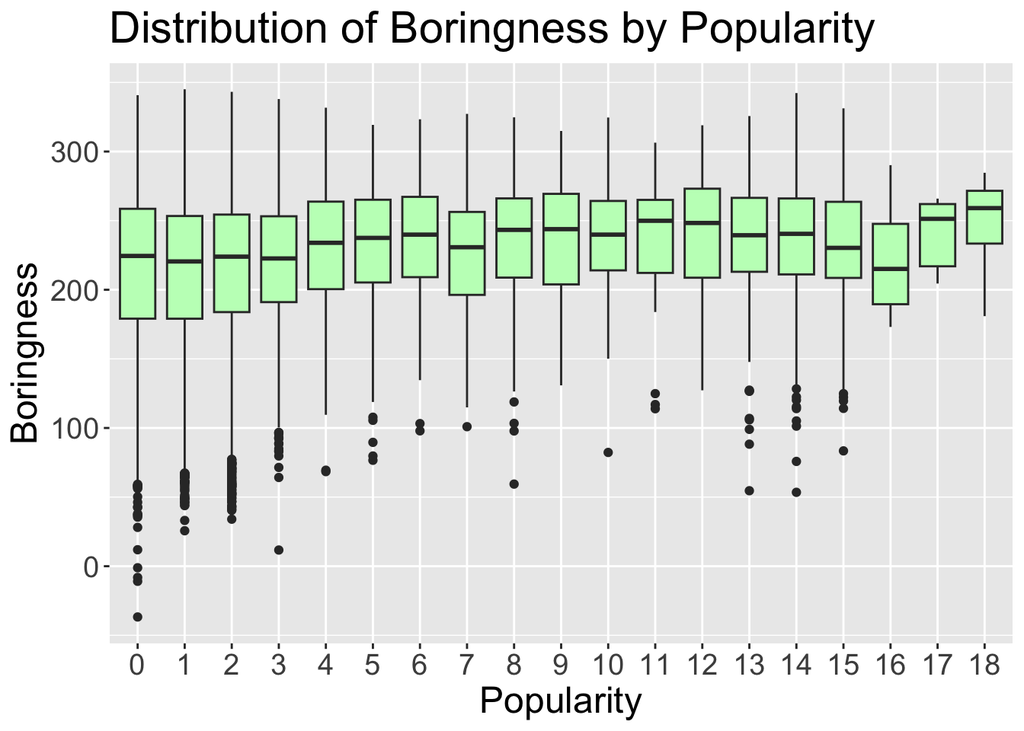

```r
ggplot(songs, aes(x=popularity, y=boringness))+
  geom_boxplot(fill="#C1FFC1")+
  labs(title="Distribution of Boringness by Popularity", x="Popularity", y="Boringness")+
  theme(text=element_text(size=18))
```

Because boringness was created by adding up loudness, tempo, energy, and danceability, I am going to assume that a high boringness value actually means a song is less boring and a low boringness value means a song is more boring. This would mean that most songs in this dataset are not very boring. The median is similar for all popularity and is between 200 and 300. There are small outliers, the most and smallest belong to the least popular songs. This would mean that the least popular songs are most boring which makes sense.